# HW3 Solution

HW 3 - Due Tuesday Sept 20, 2016. Upload R file to Moodle with name: HW3_490IDS_YOURNETID.R. Do Not remove any of the comments. These are marked by #. The .R file will contain your code and answers to questions.

Name:X

Main topic: Using the “apply” family function

### Q1 (5 pts)

Given a function below,

```r
myfunc <- function(z) return(c(z,z^2, z^3%/%2))
```

#### (1)

Examine the following code, and briefly explain what it is doing.

```r
y = 2:8
myfunc(y)
```

```
##  [1]   2   3   4   5   6   7   8   4   9  16  25  36  49  64   4  13  32
## [18]  62 108 171 256
```

```r
matrix(myfunc(y),ncol=3)
```

```
##      [,1] [,2] [,3]
## [1,]    2    4    4
## [2,]    3    9   13
## [3,]    4   16   32
## [4,]    5   25   62
## [5,]    6   36  108
## [6,]    7   49  171
## [7,]    8   64  256
```

*Given y as input, using myfunc to get a vector of numbers and change it into a matrix.The columns in the matrix are y, y^2 and y^3 divided by 2.*

#### (2)

Simplify the code in (1) using one of the “apply” functions and save the result as m.

```r
m = t(sapply(y, myfunc))
m
```

```
##      [,1] [,2] [,3]
## [1,]    2    4    4
## [2,]    3    9   13
## [3,]    4   16   32
## [4,]    5   25   62
## [5,]    6   36  108
## [6,]    7   49  171
## [7,]    8   64  256
```

#### (3)

Find the row prod of m.

```r
apply(m, 1, prod)
```

```
## [1]     32    351   2048   7750  23328  58653 131072
```

#### (4)

Find the column sum of m in two ways.

```r
apply(m,2,sum)
```

```
## [1]  35 203 646
```

```r
colSums(m)
```

```
## [1]  35 203 646
```

#### (5)

Could you divide all the values by 2 in two ways?

```r
apply(m,1:2,function(x) x/2)
```

```
##      [,1] [,2]  [,3]
## [1,]  1.0  2.0   2.0
## [2,]  1.5  4.5   6.5
## [3,]  2.0  8.0  16.0
## [4,]  2.5 12.5  31.0
## [5,]  3.0 18.0  54.0
## [6,]  3.5 24.5  85.5
## [7,]  4.0 32.0 128.0
```

```r
m/2
```

```
##      [,1] [,2]  [,3]
## [1,]  1.0  2.0   2.0
## [2,]  1.5  4.5   6.5
## [3,]  2.0  8.0  16.0
## [4,]  2.5 12.5  31.0
## [5,]  3.0 18.0  54.0
## [6,]  3.5 24.5  85.5
## [7,]  4.0 32.0 128.0
```

### Q2 (8 ts)

Create a list with 2 elements as follows:

```r
l <- list(a = 1:10, b = 11:20)
```

#### (1)

What is the product of the values in each element?

```r
lapply(l, prod)
```

```
## $a
## [1] 3628800
##
## $b
## [1] 670442572800
```

#### (2)

What is the (sample) variance of the values in each element?

```r
lapply(l, var)
```

```
## $a
## [1] 9.166667
##
## $b
## [1] 9.166667
```

#### (3)

What type of object is returned if you use lapply? sapply? Show your R code that finds these answers.

```r
class(lapply(l,prod))
```

```
## [1] "list"
```

```r
class(sapply(l,prod))
```

```
## [1] "numeric"
```

*lapply and sapply work in a similar way, traversing over a set of data like a list or vector, and calling the specified function for each item. However, lapply will always return a list instead of a vector.*

Now create the following list:

```r
l.2 <- list(c = c(21:30), d = c(31:40))
```

#### (4)

What is the sum of the corresponding elements of l and l.2, using one function call?

```r
mapply(sum, l$a, l$b, l.2$c, l.2$d)
```

```
##  [1]  64  68  72  76  80  84  88  92  96 100
```

or

```r
Reduce("+", c(l, l.2))
```

```
##  [1]  64  68  72  76  80  84  88  92  96 100
```

#### (5)

Take the log of each element in the list l:

```r
rapply(l, log2, how = "list")
```

```
## $a
##  [1] 0.000000 1.000000 1.584963 2.000000 2.321928 2.584963 2.807355
##  [8] 3.000000 3.169925 3.321928
##
## $b
##  [1] 3.459432 3.584963 3.700440 3.807355 3.906891 4.000000 4.087463
##  [8] 4.169925 4.247928 4.321928
```

```r
lapply(l, log2)
```

```
## $a
##  [1] 0.000000 1.000000 1.584963 2.000000 2.321928 2.584963 2.807355
##  [8] 3.000000 3.169925 3.321928
##
## $b
##  [1] 3.459432 3.584963 3.700440 3.807355 3.906891 4.000000 4.087463
##  [8] 4.169925 4.247928 4.321928
```

*the log function could be log, log2, log10, etc.*

#### (6)

First change l and l.2 into matrixes, make each element in the list as column,

```r
l = matrix(unlist(l), ncol = 2)
l.2 = matrix(unlist(l.2), ncol = 2)
```

*or l = sapply(l, unlist), l.2 = sapply(l.2, unlist), l = sapply(l, ‘[’), l = simplify2array(l) or l= sapply(l, matrix)*

Then, form a list named mylist using l,l.2 and m (from Q1) (in this order).

```r
mylist = list(l, l.2, m)
```

Then, select the first column of each elements in mylist in one function call (hint ‘[’ is the select operator).

```r
lapply(mylist,'[', ,1)
```

```
## [[1]]
##  [1]  1  2  3  4  5  6  7  8  9 10
##
## [[2]]
##  [1] 21 22 23 24 25 26 27 28 29 30
##
## [[3]]
## [1] 2 3 4 5 6 7 8
```

### Q3 (3 pts)

Let’s load our friend family data again.

```r
load(url("http://courseweb.lis.illinois.edu/~jguo24/family.rda"))
```

#### (1)

Find the mean bmi by gender in one function call.

```r
tapply(family$bmi, family$gender, mean)
```

```
##        m        f
## 25.73898 23.02564
```

#### (2)

Could you get a vector of what the type of variables the dataset is made of.

```r
sapply(family,class)
```

```
## firstName    gender       age    height    weight       bmi    overWt
##  "factor"  "factor" "integer" "numeric" "integer" "numeric" "logical"
```

#### (3)

Could you sort the firstName in height descending order?

```r
family$firstName[order(family$height, decreasing = TRUE)]
```

```
##  [1] Joe Tom Tom Liz Jon Tim Bob Ann Dan Art Sal May Sue Zoe
## Levels: Ann Art Bob Dan Joe Jon Liz May Sal Sue Tim Tom Zoe
```

```r
family[order(family$height, decreasing = TRUE),]$firstName
```

```
##  [1] Joe Tom Tom Liz Jon Tim Bob Ann Dan Art Sal May Sue Zoe
## Levels: Ann Art Bob Dan Joe Jon Liz May Sal Sue Tim Tom Zoe
```

### Q4 (2 pts)

There is a famous dataset in R called “iris.” It should already be loaded in R for you. If you type in ?iris you can see some documentation. Familiarize yourself with this dataset.

#### (1)

Find the mean petal length by species.

```r
tapply(iris$Petal.Length, iris$Species, mean)
```

```
##     setosa versicolor  virginica
##      1.462      4.260      5.552
```

#### (2)

Now obtain the sum of the first 4 variables, by species, but using only one function call.

```r
by(iris[,1:4],iris$Species, colSums)
```

```
## iris$Species: setosa
## Sepal.Length  Sepal.Width Petal.Length  Petal.Width
##        250.3        171.4         73.1         12.3
## --------------------------------------------------------
## iris$Species: versicolor
## Sepal.Length  Sepal.Width Petal.Length  Petal.Width
##        296.8        138.5        213.0         66.3
## --------------------------------------------------------
## iris$Species: virginica
## Sepal.Length  Sepal.Width Petal.Length  Petal.Width
##        329.4        148.7        277.6        101.3
```

#### Q5 (2 pts)

Below are two statements, their results have different structure,

```r
lapply(1:4, function(x) x^3)
```

```
## [[1]]
## [1] 1
##
## [[2]]
## [1] 8
##
## [[3]]
## [1] 27
##
## [[4]]
## [1] 64
```

```r
sapply(1:4, function(x) x^3)
```

```
## [1]  1  8 27 64
```

Could you change one of them to make the two statements return the same results? first solution

```r
unlist(lapply(1:4, function(x) x^3))
```

```
## [1]  1  8 27 64
```

or

```r
sapply(1:4, function(x) x^3, simplify = FALSE)
```

```
## [[1]]
## [1] 1
##
## [[2]]
## [1] 8
##
## [[3]]
## [1] 27
##
## [[4]]
## [1] 64
```

#### Q6 (5 pts)

Using the family data, fit a linear regression model to predict weight from height. Place your code and output (the model) below.

```r
mod=lm(family$weight~family$height)
summary(mod)
```

```
##
## Call:
## lm(formula = family$weight ~ family$height)
##
## Residuals:
##     Min      1Q  Median      3Q     Max
## -27.554  -9.689  -0.055  11.944  23.214
##
## Coefficients:
##               Estimate Std. Error t value Pr(>|t|)
## (Intercept)   -455.666    107.029  -4.257  0.00111 **
## family$height    9.154      1.594   5.741 9.29e-05 ***
## ---
## Signif. codes:  0 '***' 0.001 '**' 0.01 '*' 0.05 '.' 0.1 ' ' 1
##
## Residual standard error: 16.94 on 12 degrees of freedom
## Multiple R-squared:  0.7331, Adjusted R-squared:  0.7109
## F-statistic: 32.96 on 1 and 12 DF,  p-value: 9.287e-05
```

How do you interpret this model?

*Both parameter estimaters are significant with low p-values. Height has positive relationship with weight, and when height increase 1 unit, height will increase 9.154 unit. The multiple R-squared value is about 73.31%. Overall, the model is okay.(Whatever reasonable interpretation.)*

Create a scatterplot of height vs weight. Add the linear regression line you found above. Provide an interpretation for your plot.

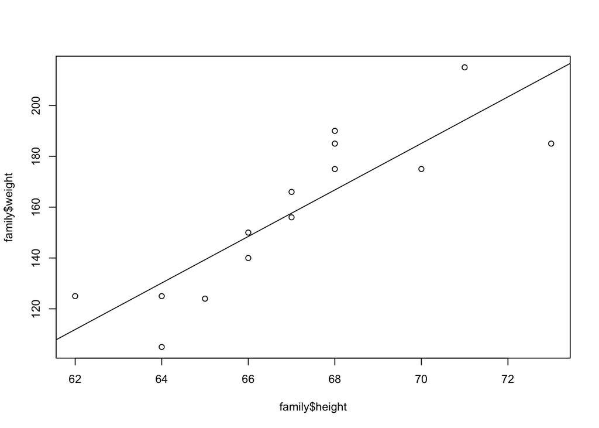

```r
par(cex=.8)
plot(family$height,family$weight)
abline(lm(mod))
```

*As we can see from the scatterplot, most of the data points are near or close to the regression line and no particular outlier or point different from others is observed. Hence, the line fits well with the data and seems to be a reasonable model.(Whatever reasonable interpretation.)*